# Natural Language Processing - Sarcasm Detection

## Description

Past studies in Sarcasm Detection mostly make use of Twitter datasets collected using hashtag based supervision but such datasets are noisy in terms of labels and language. Furthermore, many tweets are replies to other tweets and detecting sarcasm in these requires the availability of contextual tweets. In this hands-on project, the goal is to build a model to detect whether a sentence is sarcastic or not, using Bidirectional LSTMs.

## Dataset

### News Headlines for Sarcasm Detection

The dataset is collected from two news websites, theonion.com and huffingtonpost.com This new dataset has the following advantages over the existing Twitter datasets: Since news headlines are written by professionals in a formal manner, there are no spelling mistakes and informal usage. This reduces the sparsity and also increases the chance of finding pre-trained embeddings. Furthermore, since the sole purpose of TheOnion is to publish sarcastic news, we get high-quality labels with much less noise as compared to Twitter datasets. Unlike tweets that reply to other tweets, the news headlines obtained are self-contained. This would help us in teasing apart the real sarcastic elements

### Content

Each record consists of three attributes:

- is_sarcastic: 1 if the record is sarcastic otherwise 0
- headline: the headline of the news article
- article_link: link to the original news article. Useful in collecting supplementary data

## Import Packages

```python
# Mounting Google Drive
from google.colab import drive
drive.mount('/content/drive')
```

```python
# Setting the current working directory
import os;
%pwd
#os.chdir('drive/My Drive/Projects/NLP/Sarcasm Detection/')
```

```
'/content/drive/My Drive/Projects/NLP/Sarcasm Detection'
```

### Dataset

#### Acknowledgement

Misra, Rishabh, and Prahal Arora. "Sarcasm Detection using Hybrid Neural Network." arXiv preprint arXiv:1908.07414 (2019).

**Required Files given in below link.**

https://drive.google.com/file/d/19Sz3OChb-ttPJSPe2ESe3vExA2iWliQc/view?usp=sharing

```python
#Import Necessary Packages
import warnings; warnings.filterwarnings('ignore')
import pandas as pd, numpy as np, tensorflow as tf
import matplotlib.pyplot as plt, seaborn as sns
import matplotlib.style as style
import nltk; nltk.download('wordnet'); nltk.download('stopwords')

import random, re
assert tf.__version__ >= '2.0'
%matplotlib inline

# Text preprocessing and stopwords
#from text_preprocess import custom module

# Models
from tensorflow.keras.layers import Dense, LSTM, Embedding, Dropout, Flatten, Bidirectional, GlobalMaxPool1D
from tensorflow.keras.callbacks import EarlyStopping, ModelCheckpoint, ReduceLROnPlateau, TensorBoard
from tensorflow.keras.preprocessing.sequence import pad_sequences
from tensorflow.keras.preprocessing.text import Tokenizer
from tensorflow.keras.models import Model, Sequential
from tensorflow.keras.initializers import Constant

from sklearn.metrics import classification_report, confusion_matrix
from sklearn.model_selection import train_test_split

from nltk.stem import WordNetLemmatizer
from nltk.corpus import wordnet as wn
from nltk.corpus import stopwords
from wordcloud import WordCloud
import string

# Set random state
random_state = 42
np.random.seed(random_state)
tf.random.set_seed(random_state)
```

### Load Data

```python
data = pd.read_json('Sarcasm_Headlines_Dataset.json', lines = True)
```

### Visualize the data

```python
#Shape of the dataset
print('Shape of the Dataset is', data.shape)
print('Dataset has', data.shape[0], 'rows')
print('Dataset has', data.shape[1], 'columns')
```

```
Shape of the Dataset is (26709, 3)
Dataset has 26709 rows
Dataset has 3 columns
```

```python
#Display first few records of the dataset
display(data.head(10))
```

|  | article_link | headline | is_sarcastic |
| --- | --- | --- | --- |
| 0 | https://www.huffingtonpost.com/entry/versace-b... | former versace store clerk sues over secret 'b... | 0 |
| 1 | https://www.huffingtonpost.com/entry/roseanne-... | the 'roseanne' revival catches up to our thorn... | 0 |
| 2 | https://local.theonion.com/mom-starting-to-fea... | mom starting to fear son's web series closest ... | 1 |
| 3 | https://politics.theonion.com/boehner-just-wan... | boehner just wants wife to listen, not come up... | 1 |
| 4 | https://www.huffingtonpost.com/entry/jk-rowlin... | j.k. rowling wishes snape happy birthday in th... | 0 |
| 5 | https://www.huffingtonpost.com/entry/advancing... | advancing the world's women | 0 |
| 6 | https://www.huffingtonpost.com/entry/how-meat-... | the fascinating case for eating lab-grown meat | 0 |
| 7 | https://www.huffingtonpost.com/entry/boxed-col... | this ceo will send your kids to school, if you... | 0 |
| 8 | https://politics.theonion.com/top-snake-handle... | top snake handler leaves sinking huckabee camp... | 1 |
| 9 | https://www.huffingtonpost.com/entry/fridays-m... | friday's morning email: inside trump's presser... | 0 |

### Exploratory Data Analysis

```python
# Checking the Value counts  `is_sarcastic` label
print(f'Is Sarcastic count: {data[data.is_sarcastic == 1].shape[0]} i.e. {round(data[data.is_sarcastic == 1].shape[0]/data.shape[0]*100, 0)}%')
print(f'Isn\'t Sarcastic count: {data[data.is_sarcastic == 0].shape[0]} i.e. {round(data[data.is_sarcastic == 0].shape[0]/data.shape[0]*100, 0)}%')
```

```
Is Sarcastic count: 11724 i.e. 44.0%
Isn't Sarcastic count: 14985 i.e. 56.0%
```

```
Plotting the Distribution of "Is_Sarcastic" label
```

[figure not shown]

```python
#Plotting the distribution of the 'is_sarcastic_label' in the dataset
print('Plotting the Distribution of "Is_Sarcastic" label')
fig = plt.figure(figsize =(10, 7))
data['is_sarcastic'].value_counts().plot(kind = 'pie', autopct = '%.0f%%', labels = ['Sarcastic', 'Non-sarcastic'], colors = ['#82E0AA','#EC7063'], figsize =(10,6))
# show plot
plt.show()
```

```python
print('--'*30)
print('Analysis of `is_sarcastic` label by news website');
print('--'*30)
hp = data[data['article_link'].str.contains('huffingtonpost.com')].shape[0]
to = data[data['article_link'].str.contains('theonion.com')].shape[0]

is_sarcastic_hp = data.loc[(data['article_link'].str.contains('huffingtonpost.com')) & (data['is_sarcastic'] == 1)].shape[0]
not_sarcastic_hp = data.loc[(data['article_link'].str.contains('huffingtonpost.com')) & (data['is_sarcastic'] == 0)].shape[0]

is_sarcastic_to = data.loc[(data['article_link'].str.contains('theonion.com')) & (data['is_sarcastic'] == 1)].shape[0]
not_sarcastic_to = data.loc[(data['article_link'].str.contains('theonion.com')) & (data['is_sarcastic'] == 0)].shape[0]

display(pd.DataFrame([[is_sarcastic_hp, is_sarcastic_to], [not_sarcastic_hp, not_sarcastic_to]],
                     columns = ['huffingtonpost', 'theonion'], index = ['Sarcastic', 'Non-sarcastic']))
```

```
------------------------------------------------------------
Analysis of `is_sarcastic` label by news website
------------------------------------------------------------
```

|  | huffingtonpost | theonion |
| --- | --- | --- |
| Sarcastic | 0 | 11724 |
| Non-sarcastic | 14985 | 1 |

```python
# Viewing 5 random headlines and labels from the dataset
print('--'*30);
print('Checking 5 random headlines and labels from the data');
print('--'*30)
rands = random.sample(range(1, data.shape[0]), 5)
headlines, labels = list(data.loc[rands, 'headline']), list(data.loc[rands, 'is_sarcastic'])
[print(f'Headline: {head}\nlabel: {label}\n') for head, label in zip(headlines, labels)]
```

```
------------------------------------------------------------
Checking 5 random headlines and labels from the data
------------------------------------------------------------
Headline: little debbie conquers jenny craig in midnight showdown
label: 1

Headline: fda: lucky charms no longer part of complete breakfast
label: 1

Headline: the wack donald's project
label: 0

Headline: quentin tarantino calls uma thurman car crash 'biggest regret of my life'
label: 0

Headline: photos show the calais 'jungle' going up in flames
label: 0
```

```
[None, None, None, None, None]
```

```
----------------------------------------------------------------------------------------------------
Checking 5 random headlines and labels from the data where the length of headline is > 100
----------------------------------------------------------------------------------------------------
Headline: woman worried student loans could prevent her from one day owning entirely different kind of crippling debt
label: 1

Headline: 'he made the ultimate sacrifice,' trump tells military widow about scooby-doo putting up with scrappy-doo
label: 1

Headline: $80 million movie scrapped after footage reveals brad pitt had spinach stuck in teeth for entire film
label: 1

Headline: occasionally you realize someone you thought was a dear friend is actually a foe, their true character finally revealed. but how do you forgive the unforgivable? here are my 10 steps to handling betrayal with elegance and grace.
label: 0

Headline: 'wow, no one saw this coming' nation groans as norway's 'kon-tiki' nabs best foreign picture nomination
label: 1

------------------------------------------------------------
Distributon of label where the length of headline is > 100
------------------------------------------------------------
```

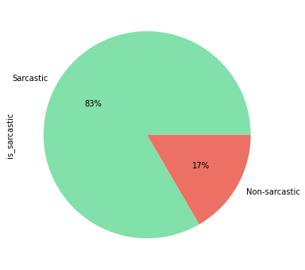

```python
# Viewing 5 random headlines and labels from the data where the length of headline is > 100
print('--'*50);
print('Checking 5 random headlines and labels from the data where the length of headline is > 100');
print('--'*50)
indexes = list(data.loc[data['headline'].str.len() > 100, 'headline'].index)
rands = random.sample(indexes, 5)
headlines, labels = list(data.loc[rands, 'headline']), list(data.loc[rands, 'is_sarcastic'])
[print(f'Headline: {head}\nlabel: {label}\n') for head, label in zip(headlines, labels)]

print('--'*30);
print('Distributon of label where the length of headline is > 100');
print('--'*30)
data.loc[indexes, 'is_sarcastic'].value_counts().plot(kind = 'pie', autopct = '%.0f%%', labels = ['Sarcastic', 'Non-sarcastic'], colors = ['#82E0AA','#EC7063'], figsize =(10,6))
```

### Observations

- 44% of the data have sarcastic labels whereas 56% don't.
- There are no headlines from HuffPost that are sarcastic whereas all but one from The Onion are sarcastic.
- Based on some random headlines seen above, it appears that the data is mostly lower-cased. Pre-processing such as removing punctuations and lemmatization can be used.
- 83% of data where length of sentence (headlines) > 100 are sarcastic headlines.

### Drop `article_link` from dataset

```python
print('Dropping `article_link` from the data'); print('--'*30)
data.drop('article_link', axis = 1, inplace = True)
```

```
Dropping `article_link` from the data
------------------------------------------------------------
```

### Data Preprocessing

Few of the data pre-processing steps taken before applying model on the data

```python
nltk.download('averaged_perceptron_tagger')
```

```
True
```

```python
# Helper function to replace appos
def replace_words(headline):
    cleaned_headlines = []
    for word in str(headline).split():
        if word.lower() in appos.keys():
            cleaned_headlines.append(appos[word.lower()])
        else:
            cleaned_headlines.append(word)
    return ' '.join(cleaned_headlines)

# Helper function to remove punctuations
# Reference: https://www.programiz.com/python-programming/methods/string/translate
PUNCT_TO_REMOVE = '!"#$%&\'()*+,-./:;<=>?@[\\]^_`{|}~' #string.punctuation
def remove_punctuation(text):
    """function to remove the punctuation"""
    return text.translate(str.maketrans('', '', PUNCT_TO_REMOVE))

# Helper function to lemmatize
lemmatizer = WordNetLemmatizer()
def lemmatize(text):
  return ''.join([lemmatizer.lemmatize(word) for word in text])

# Helper function to remove stopwords
stoplist = set(stopwords.words('english'))
stoplist.remove('not')
def remove_stopwords(text):
    """function to remove the stopwords"""
    return " ".join([word for word in str(text).split() if word not in stoplist])

# Helper function for wordcloud
# Reference: https://www.kaggle.com/aashita/word-clouds-of-various-shapes
def plot_wordcloud(text, mask = None, max_words = 500, max_font_size = 40,
                   figure_size = (12, 6), title = None, title_size = 15):
    wordcloud = WordCloud(background_color = 'white', max_words = max_words,
                          random_state = 42, width = 350, height = 150,
                          mask = mask, stopwords = stoplist, collocations = False)
    wordcloud.generate(str(text))

    plt.figure(figsize = figure_size)
    plt.imshow(wordcloud, interpolation = 'bilinear');
    plt.title(title, fontdict = {'size': title_size, 'color': 'black',
                               'verticalalignment': 'bottom'})
    plt.axis('off');
    plt.tight_layout()

# Second helper function for lemmatizing
lemmatizer = WordNetLemmatizer()
def lem(text):
    pos_dict = {'N': wn.NOUN, 'V': wn.VERB, 'J': wn.ADJ, 'R': wn.ADV}
    return(' '.join([lemmatizer.lemmatize(w,pos_dict.get(t, wn.NOUN)) for w,t in nltk.pos_tag(text.split())]))
```

```python
print('--'*30); print('Converting headlines to lower case')
data['cleaned_headline'] = data['headline'].apply(lambda x : x.lower())

#print('Replacing apostrophes to the standard lexicons')
#data['cleaned_headline'] = data['cleaned_headline'].apply(lambda x : replace_words(x))

print('Removing punctuations')
data['cleaned_headline'] = data['cleaned_headline'].apply(lambda x: remove_punctuation(x))

print('Applying Lemmatizer')
data['cleaned_headline'] = data['cleaned_headline'].apply(lambda x: lem(x))

print('Removing multiple spaces between words')
data['cleaned_headline'] = data['cleaned_headline'].apply(lambda x: re.sub(' +', ' ', x))

# print('Removing stopwords')
# data['cleaned_headline'] = data['cleaned_headline'].apply(lambda x: remove_stopwords(x))
print('--'*30)
```

```
------------------------------------------------------------
Converting headlines to lower case
Removing punctuations
Applying Lemmatizer
Removing multiple spaces between words
------------------------------------------------------------
```

### Get length of each headline and add a column for that

### Initialize parameter values

- Set values for max_features, maxlen, & embedding_size
- max_features: Number of words to take from tokenizer(most frequent words)
- maxlen: Maximum length of each sentence to be limited to 25
- embedding_size: size of embedding vector

```python
print('--'*40); print('Get the number of words, find the maximum number of words and print the maximum number of words');
print('Number of words ranges from 2 to 39.'); print('--'*40)
# Get length of each line
data['nb_words'] = data['cleaned_headline'].apply(lambda x: len(x.split(' ')))

print('Minimum number of words: {}'.format(data['nb_words'].min()))
print('Maximum number of words: {}'.format(data['nb_words'].max()))
print('Line with maximum number of words: {}'.format(data[data['nb_words'] == data['nb_words'].max()]['cleaned_headline'].values[0]))
```

```
--------------------------------------------------------------------------------
Get the number of words, find the maximum number of words and print the maximum number of words
Number of words ranges from 2 to 39.
--------------------------------------------------------------------------------
Minimum number of words: 2
Maximum number of words: 39
Line with maximum number of words: elmore leonard modern prose master noted for his terse prose style and for writing about thing perfectly and succinctly with a remarkable economy of word unfortunately and sadly expired this gloomy tuesday at the age of 87 year old
```

```
Word Cloud of Sarcastic and Non-sarcastic Headlines
```

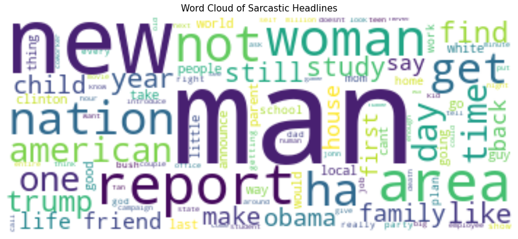

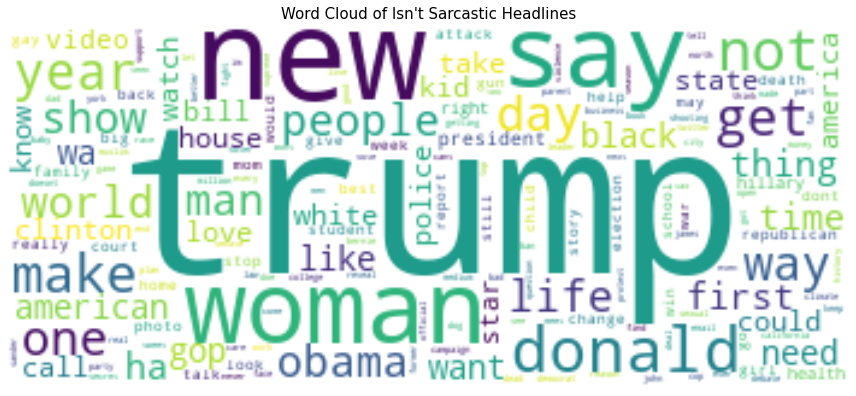

```python
print('Word Cloud of Sarcastic and Non-sarcastic Headlines')
data['headline'] = data['headline'].fillna('')
sarcastic_headlines = ' '.join(data.loc[data['is_sarcastic'] == 1, 'cleaned_headline'])
plot_wordcloud(sarcastic_headlines, title = 'Word Cloud of Sarcastic Headlines')

non_sarcastic_headlines = ' '.join(data.loc[data['is_sarcastic'] == 0, 'cleaned_headline'])
plot_wordcloud(non_sarcastic_headlines, title = 'Word Cloud of Isn\'t Sarcastic Headlines')
```

### Modelling

```python
print('--'*30);
print('Five point summary for number of words')
print('--'*30)
display(data['nb_words'].describe().round(0).astype(int));
print('99% quantilie: {}'.format(data['nb_words'].quantile(0.99)));
```

```
------------------------------------------------------------
Five point summary for number of words
------------------------------------------------------------
```

```
count    26709
mean        10
std          3
min          2
25%          8
50%         10
75%         12
max         39
Name: nb_words, dtype: int64
```

```
99% quantilie: 18.0
```

##### **Set Different Parameters for the model**

```python
max_features = 10000
maxlen = 25
embedding_size = 200
```

### Apply `tensorflow.keras` Tokenizer and get indices for words

- Initialize Tokenizer object with number of words as 10000
- Fit the tokenizer object on headline column
- Convert the text to sequence

```python
tokenizer = Tokenizer(num_words = max_features)
tokenizer.fit_on_texts(list(data['cleaned_headline']))
```

### Pad sequences

- Pad each example with a maximum length
- Convert target column into numpy array

```python
#As different lines are of different length. We need to pad the our sequences using the max length.
print('--'*40); print('Get the length of each line, find the maximum length and print the maximum length line');
print('Length of line ranges from 7 to 241.'); print('--'*40)
# Get length of each line
data['line_length'] = data['cleaned_headline'].str.len()

print('Minimum line length: {}'.format(data['line_length'].min()))
print('Maximum line length: {}'.format(data['line_length'].max()))
print('Line with maximum length: {}'.format(data[data['line_length'] == data['line_length'].max()]['cleaned_headline'].values[0]))
```

```
--------------------------------------------------------------------------------
Get the length of each line, find the maximum length and print the maximum length line
Length of line ranges from 7 to 241.
--------------------------------------------------------------------------------
Minimum line length: 7
Maximum line length: 241
Line with maximum length: maya angelou poet author civil right activist and—holy cow—tony award–nominated actress college professor magazine editor streetcar conductor—really streetcar conductor wow—calypso singer nightclub performer and foreign journalist dead at 86
```

### Vocab mapping

- There is no word for 0th index

```python
tokenizer.word_index
```

```
{'to': 1,
 'of': 2,
 'the': 3,
 'in': 4,
 'a': 5,
 'for': 6,
 'on': 7,
 'and': 8,
 'with': 9,
 'is': 10,
 'trump': 11,
 'new': 12,
 'man': 13,
 'from': 14,
 'it': 15,
 'at': 16,
 'about': 17,
 'you': 18,
 'this': 19,
 'by': 20,
 'woman': 21,
 'after': 22,
 'be': 23,
 'how': 24,
 'out': 25,
 'that': 26,
 'up': 27,
 'he': 28,
 'not': 29,
 'say': 30,
 'are': 31,
 'your': 32,
 'what': 33,
 'his': 34,
 'who': 35,
 'report': 36,
 'get': 37,
 'just': 38,
 'u': 39,
 'ha': 40,
```

[output cut: 946 more lines]

```
 'worse': 987,
 'writer': 988,
 'culture': 989,
 'arrested': 990,
 'driving': 991,
 'target': 992,
 'leaving': 993,
 'scene': 994,
 'amid': 995,
 'bowl': 996,
 'wear': 997,
 'spring': 998,
 'repeal': 999,
 'netflix': 1000,
 ...}
```

### Set number of words

- Since the above 0th index doesn't have a word, add 1 to the length of the vocabulary

```python
num_words = len(tokenizer.word_index) + 1
print(num_words)
```

```
24981
```

### Load Glove Word Embeddings

##### **Get Glove Word Embeddings**

```python
glove_file = './Data/glove.6B.zip'
```

### Create embedding matrix

**Get Glove Word Embeddings**

```python
EMBEDDING_FILE = './glove.6B.200d.txt'

embeddings = {}
for o in open(EMBEDDING_FILE):
    word = o.split(" ")[0]
    # print(word)
    embd = o.split(" ")[1:]
    embd = np.asarray(embd, dtype='float32')
    # print(embd)
    embeddings[word] = embd
```

**Get word embeddings using embedding file**

```python
EMBEDDING_FILE = './glove.6B.200d.txt'

embeddings = {}
for o in open(EMBEDDING_FILE):
    word = o.split(' ')[0]
    embd = o.split(' ')[1:]
    embd = np.asarray(embd, dtype = 'float32')
    embeddings[word] = embd
```

**Create a weight matrix**

```python
# Getting the minimum number of words
num_words = min(max_features, vocab_size) + 1

embedding_matrix = np.zeros((num_words, embedding_size))
for word, i in tokenizer.word_index.items():
    if i > max_features: continue
    embedding_vector = embeddings.get(word)
    if embedding_vector is not None:
        embedding_matrix[i] = embedding_vector

len(embeddings.values())
```

```
400000
```

### Define model

- Hint: Use Sequential model instance and then add Embedding layer, Bidirectional(LSTM) layer, flatten it, then dense and dropout layers as required. In the end add a final dense layer with sigmoid activation for binary classification.

```python
#Define X and y for your model
X = tokenizer.texts_to_sequences(data['cleaned_headline'])
X = pad_sequences(X, maxlen = maxlen)
y = np.asarray(data['is_sarcastic'])

print(f'Number of Samples: {len(X)}')
print(f'Number of Labels: {len(y)}')
print(f'\nFirst headline:\n{X[0]}\n\nLabel of the first headline: {y[0]}')
```

```
Number of Samples: 26709
Number of Labels: 26709

First headline:
[   0    0    0    0    0    0    0    0    0    0    0    0    0    0
  330  694 2947 1268   54  293  102 1933    6 2033 3633]

Label of the first headline: 0
```

```python
x_train, x_test, y_train, y_test = train_test_split(X, y, test_size = 0.2, random_state = random_state, shuffle = True)

print('---'*20, f'\nNumber of rows in training dataset: {x_train.shape[0]}')
print(f'Number of columns in training dataset: {x_train.shape[1]}')
print(f'Number of unique words in training dataset: {len(np.unique(np.hstack(x_train)))}')

print('---'*20, f'\nNumber of rows in test dataset: {x_test.shape[0]}')
print(f'Number of columns in test dataset: {x_test.shape[1]}')
print(f'Number of unique words in test dataset: {len(np.unique(np.hstack(x_test)))}')
```

```
------------------------------------------------------------
Number of rows in training dataset: 21367
Number of columns in training dataset: 25
Number of unique words in training dataset: 9960
------------------------------------------------------------
Number of rows in test dataset: 5342
Number of columns in test dataset: 25
Number of unique words in test dataset: 7415
```

```python
#Define the Model
model = Sequential()
model.add(Embedding(num_words, embedding_size, embeddings_initializer = Constant(embedding_matrix), input_length = maxlen, trainable = False))
model.add(Bidirectional(LSTM(128, return_sequences = True)))
model.add(GlobalMaxPool1D())
model.add(Dropout(0.5, input_shape = (256,)))
model.add(Dense(128, activation = 'relu'))
model.add(Dropout(0.5, input_shape = (128,)))
model.add(Dense(64, activation = 'relu'))
model.add(Dropout(0.5, input_shape = (64,)))
model.add(Dense(1, activation = 'sigmoid'))
```